# Stat. 652: Final_pe7112

Author

Prof. Eric A. Suess

Answer two questions:

1. What are the important variables identified by the Boruta algorithm from the **Ozone** data?

**Answer:**

**Unimportant attributes:** v2 , v3 , v6.

Boruta.Short got 2 tentative attributes v2,v6 due to less number of iterations. After applying TentativeRoughFix function these are classified as unimportant attributes

2. What are the important variables identified by the Boruta algorithm from the **titanic training** data?

**Answer:**

**Important attributes:** “pclass”, “sex” “age” “sib_sp” “parch” “ticket” “fare” “cabin” “embarked”.

**Unimportant attributes:** “PassengerId”.

**Tentative attributes:** “Name”

After applying TentativeRoughFix function the “name” attribute is classified under important attributes.

```r
library(pacman)
p_load(tidyverse, janitor, naniar, DataExplorer, Boruta, mlbench)
```

```r
data(Ozone)

head(Ozone)
```

```
  V1 V2 V3 V4   V5 V6 V7 V8    V9  V10 V11   V12 V13
1  1  1  4  3 5480  8 20 NA    NA 5000 -15 30.56 200
2  1  2  5  3 5660  6 NA 38    NA   NA -14    NA 300
3  1  3  6  3 5710  4 28 40    NA 2693 -25 47.66 250
4  1  4  7  5 5700  3 37 45    NA  590 -24 55.04 100
5  1  5  1  5 5760  3 51 54 45.32 1450  25 57.02  60
6  1  6  2  6 5720  4 69 35 49.64 1568  15 53.78  60
```

Note that the target variable is V4 = Daily maximum one-hour-average ozone reading.

Convert V1, V2, and V3 to integers.

```r
Ozone <- Ozone %>% mutate(
  V1 = as.integer(V1),
  V2 = as.integer(V2),
  V3 = as.integer(V3)
)

head(Ozone)
```

```
  V1 V2 V3 V4   V5 V6 V7 V8    V9  V10 V11   V12 V13
1  1  1  4  3 5480  8 20 NA    NA 5000 -15 30.56 200
2  1  2  5  3 5660  6 NA 38    NA   NA -14    NA 300
3  1  3  6  3 5710  4 28 40    NA 2693 -25 47.66 250
4  1  4  7  5 5700  3 37 45    NA  590 -24 55.04 100
5  1  5  1  5 5760  3 51 54 45.32 1450  25 57.02  60
6  1  6  2  6 5720  4 69 35 49.64 1568  15 53.78  60
```

```r
Ozone2 <- Ozone %>% clean_names()

head(Ozone2)
```

```
  v1 v2 v3 v4   v5 v6 v7 v8    v9  v10 v11   v12 v13
1  1  1  4  3 5480  8 20 NA    NA 5000 -15 30.56 200
2  1  2  5  3 5660  6 NA 38    NA   NA -14    NA 300
3  1  3  6  3 5710  4 28 40    NA 2693 -25 47.66 250
4  1  4  7  5 5700  3 37 45    NA  590 -24 55.04 100
5  1  5  1  5 5760  3 51 54 45.32 1450  25 57.02  60
6  1  6  2  6 5720  4 69 35 49.64 1568  15 53.78  60
```

It is always a good idea to check for duplicate records/examples/rows in your dataset.

```r
get_dupes(Ozone2)
```

```
No variable names specified - using all columns.
```

```
No duplicate combinations found of: v1, v2, v3, v4, v5, v6, v7, v8, v9, ... and 4 other variables
```

```
 [1] v1         v2         v3         v4         v5         v6
 [7] v7         v8         v9         v10        v11        v12
[13] v13        dupe_count
<0 rows> (or 0-length row.names)
```

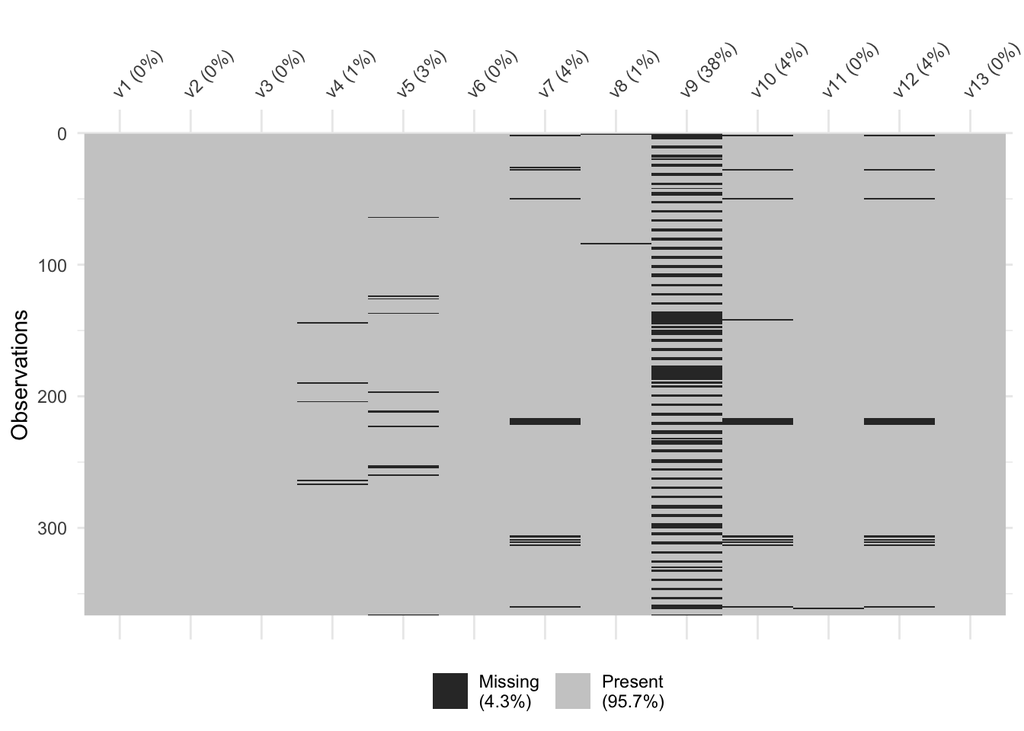

```r
vis_miss(Ozone2)
```

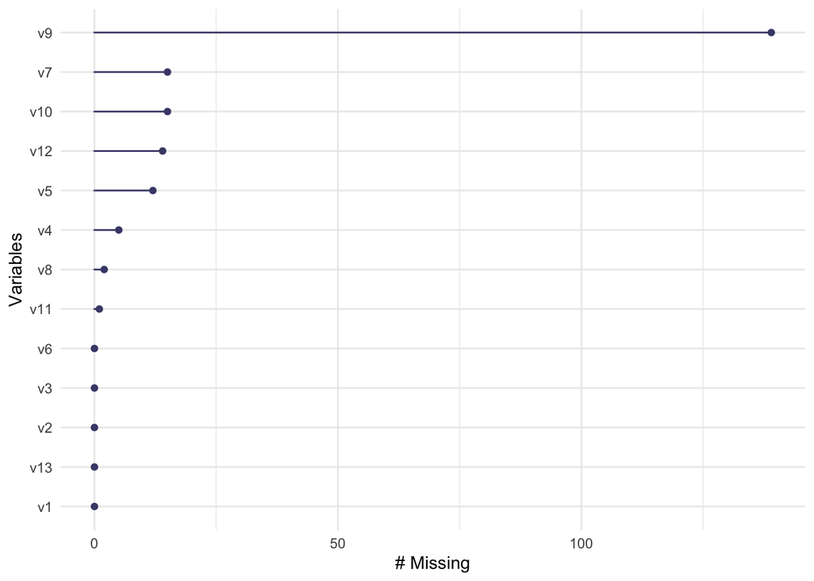

```r
gg_miss_var(Ozone2)
```

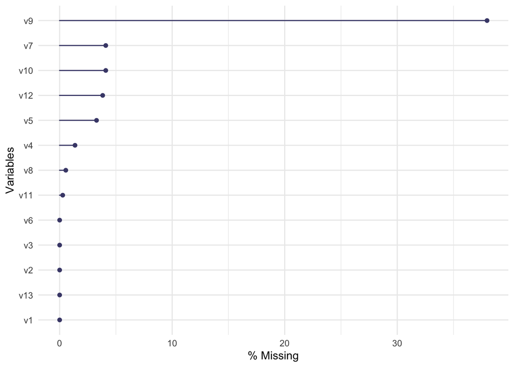

```r
gg_miss_var(Ozone2, show_pct = TRUE)
```

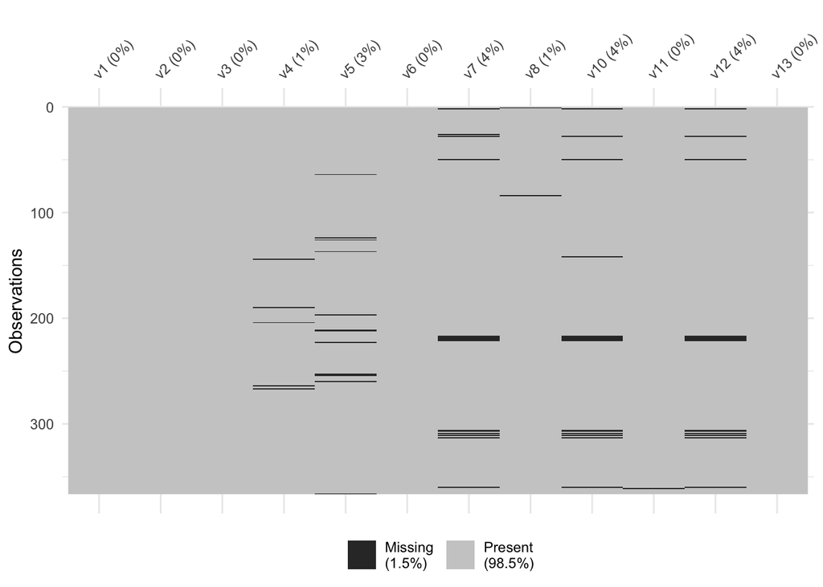

```r
Ozone2 <- Ozone2 %>% select(-v9)

vis_miss(Ozone2)
```

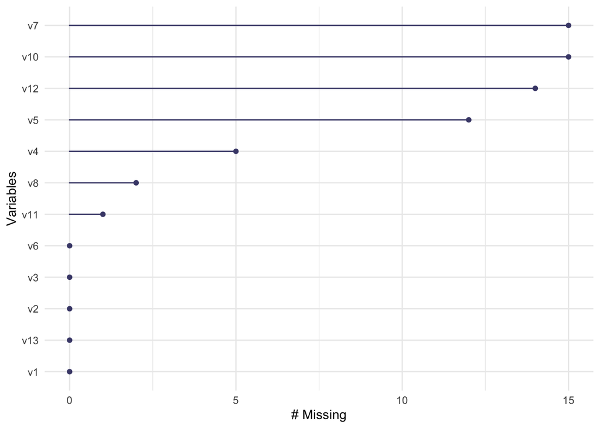

```r
gg_miss_var(Ozone2)
```

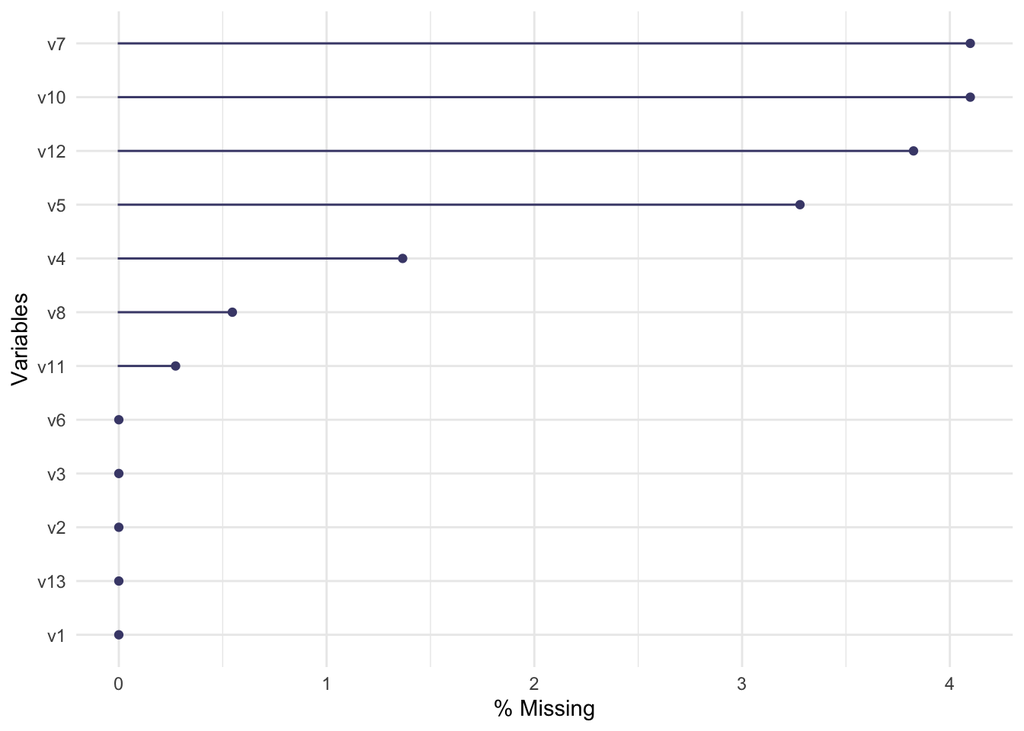

```r
gg_miss_var(Ozone2, show_pct = TRUE)
```

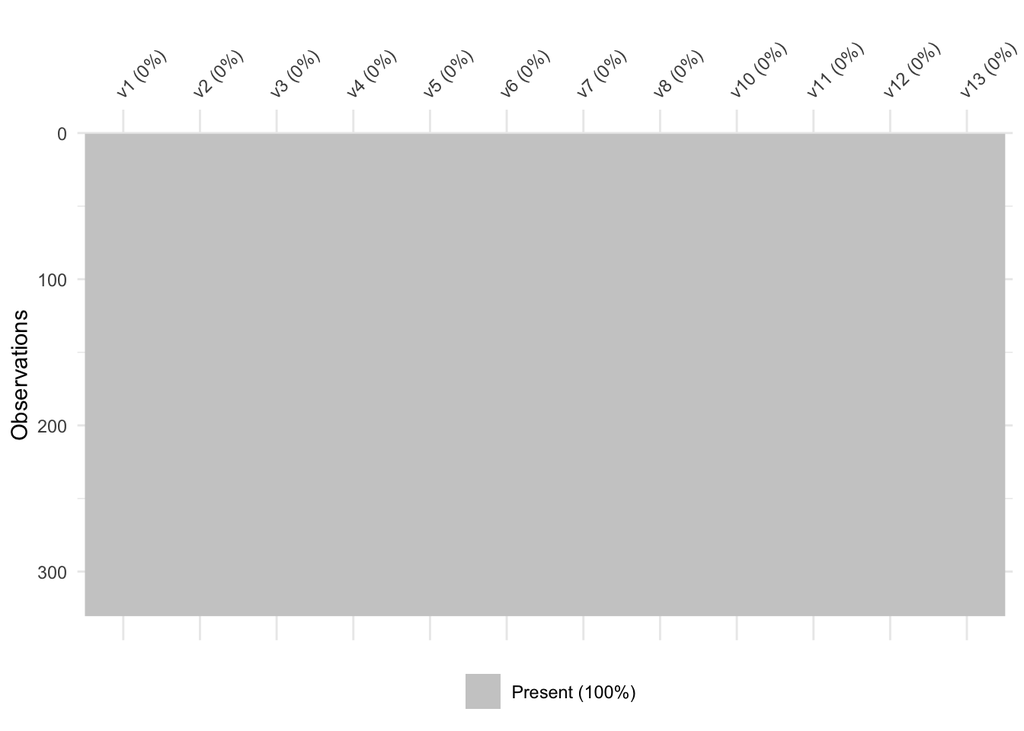

```r
Ozone2 <- drop_na(Ozone2)

vis_miss(Ozone2)
```

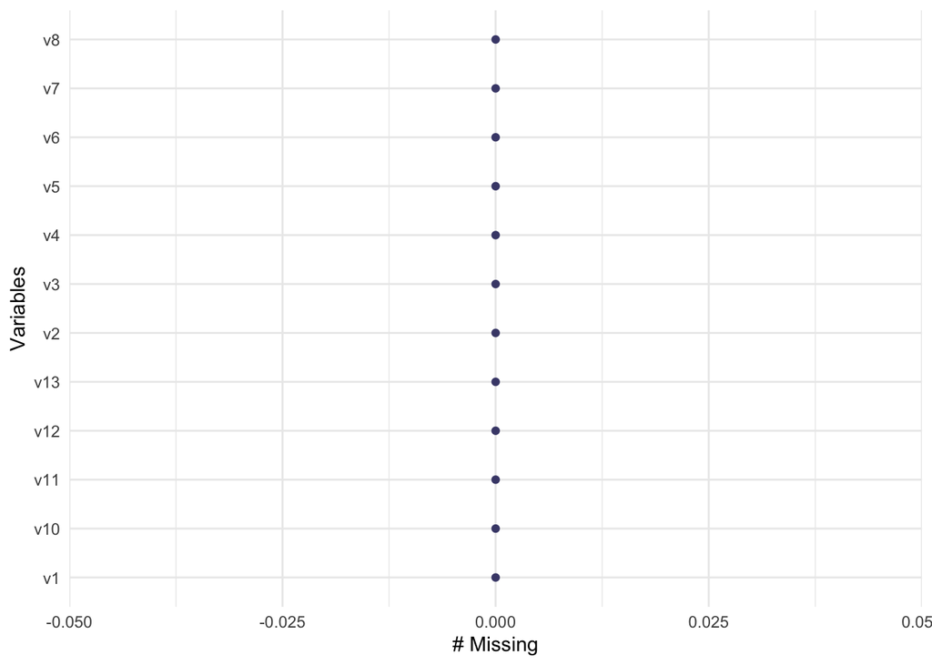

```r
gg_miss_var(Ozone2)
```

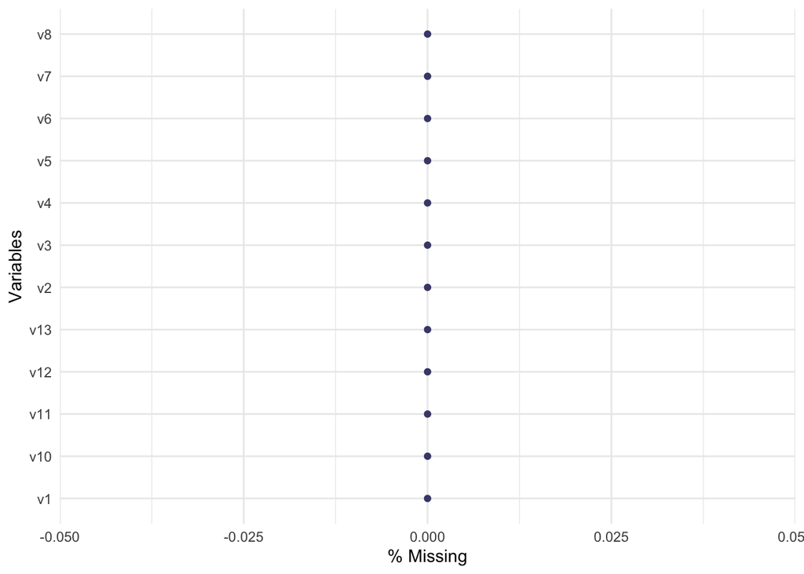

```r
gg_miss_var(Ozone2, show_pct = TRUE)
```

```r
Boruta.Ozone <- Boruta(v4 ~ ., data = Ozone2, doTrace = 2, ntree = 500)
```

[output not shown]

[output not shown]

[output not shown]

[output not shown]

[output not shown]

[output not shown]

[output not shown]

[output not shown]

[output not shown]

[output not shown]

[output not shown]

```
After 11 iterations, +1.1 secs:
```

```
 confirmed 8 attributes: v1, v10, v11, v12, v13 and 3 more;
```

```
 rejected 1 attribute: v3;
```

```
 still have 2 attributes left.
```

[output not shown]

[output not shown]

[output not shown]

[output not shown]

[output not shown]

[output not shown]

[output not shown]

[output not shown]

[output not shown]

[output not shown]

[output not shown]

[output not shown]

[output not shown]

[output not shown]

[output not shown]

[output not shown]

[output not shown]

[output not shown]

[output not shown]

[output not shown]

[output not shown]

[output not shown]

[output not shown]

[output not shown]

[output not shown]

[output not shown]

[output not shown]

[output not shown]

[output not shown]

[output not shown]

[output not shown]

[output not shown]

[output not shown]

[output not shown]

[output not shown]

[output not shown]

[output not shown]

[output not shown]

[output not shown]

[output not shown]

[output not shown]

[output not shown]

[output not shown]

[output not shown]

[output not shown]

[output not shown]

[output not shown]

[output not shown]

[output not shown]

[output not shown]

[output not shown]

[output not shown]

[output not shown]

[output not shown]

[output not shown]

[output not shown]

[output not shown]

[output not shown]

```
After 69 iterations, +3.5 secs:
```

```
 rejected 1 attribute: v2;
```

```
 still have 1 attribute left.
```

[output not shown]

[output not shown]

[output not shown]

```
After 72 iterations, +3.7 secs:
```

```
 rejected 1 attribute: v6;
```

```
 no more attributes left.
```

```r
Boruta.Ozone
```

```
Boruta performed 72 iterations in 3.696673 secs.
 8 attributes confirmed important: v1, v10, v11, v12, v13 and 3 more;
 3 attributes confirmed unimportant: v2, v3, v6;
```

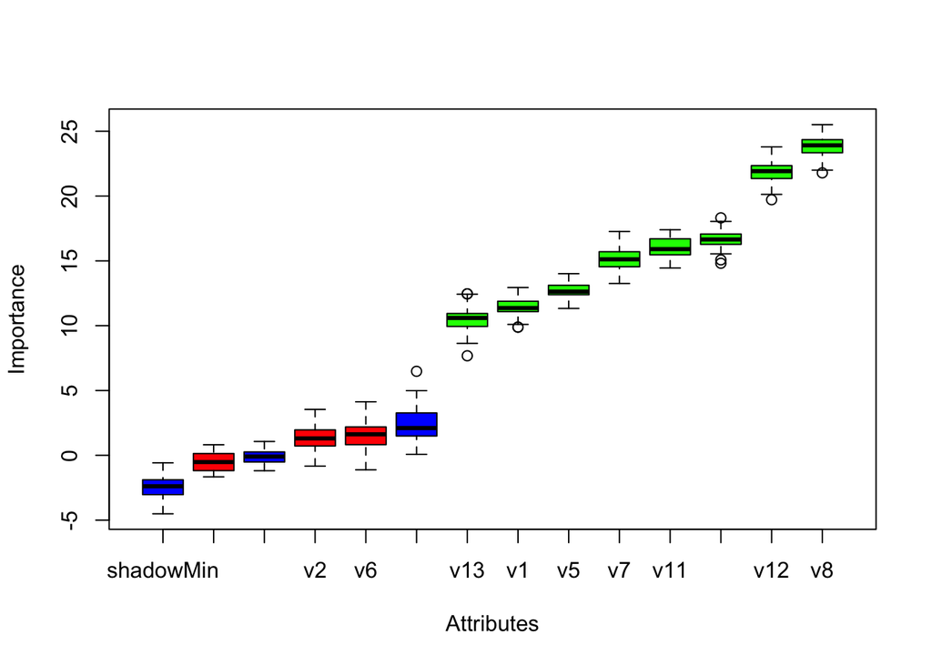

```r
plot(Boruta.Ozone)
```

```r
Boruta.Short <- Boruta(v4 ~ ., data = Ozone2, maxRuns = 12)
```

```r
Boruta.Short
```

```
Boruta performed 11 iterations in 0.6339431 secs.
 8 attributes confirmed important: v1, v10, v11, v12, v13 and 3 more;
 1 attributes confirmed unimportant: v3;
 2 tentative attributes left: v2, v6;
```

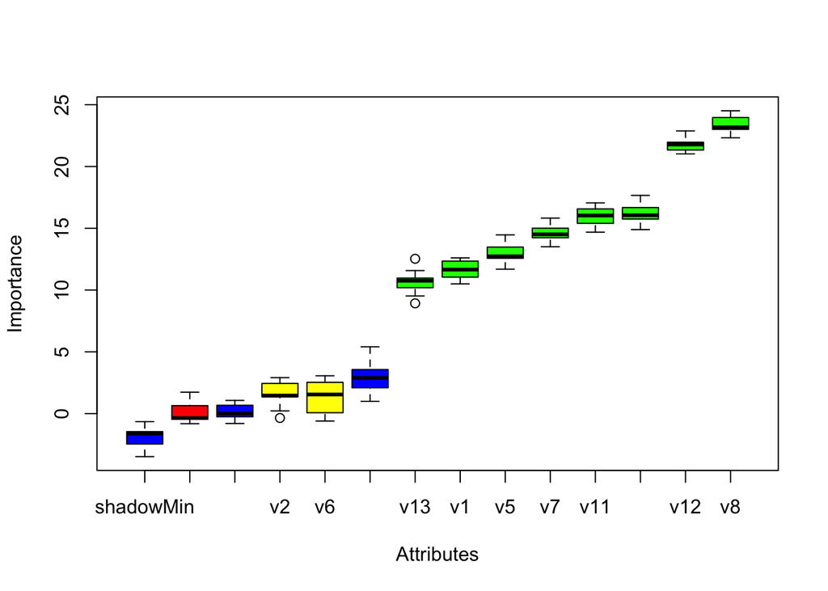

```r
plot(Boruta.Short)
```

```r
TentativeRoughFix(Boruta.Short)
```

```
Boruta performed 11 iterations in 0.6339431 secs.
Tentatives roughfixed over the last 11 iterations.
 8 attributes confirmed important: v1, v10, v11, v12, v13 and 3 more;
 3 attributes confirmed unimportant: v2, v3, v6;
```

```r
getConfirmedFormula(Boruta.Ozone)
```

```
v4 ~ v1 + v5 + v7 + v8 + v10 + v11 + v12 + v13
<environment: 0x13532a8d0>
```

```r
attStats(Boruta.Ozone)
```

```
       meanImp medianImp     minImp     maxImp  normHits  decision
v1  11.4544240 11.361793  9.8844210 12.9414031 1.0000000 Confirmed
v2   1.4159998  1.306621 -0.8322882  3.5399017 0.2916667  Rejected
v3  -0.4969956 -0.520568 -1.6625201  0.8136939 0.0000000  Rejected
v5  12.6837824 12.627922 11.3290480 14.0113056 1.0000000 Confirmed
v6   1.5956225  1.622957 -1.1204900  4.1269143 0.3055556  Rejected
v7  15.1554382 15.118456 13.2534212 17.2649185 1.0000000 Confirmed
v8  23.8483473 23.915786 21.7897509 25.5105705 1.0000000 Confirmed
v10 16.6355948 16.652225 14.8161172 18.3200733 1.0000000 Confirmed
v11 15.9917535 15.908076 14.4523759 17.4028858 1.0000000 Confirmed
v12 21.8185330 21.918910 19.7175322 23.7925033 1.0000000 Confirmed
v13 10.5032982 10.596527  7.6781358 12.4595675 1.0000000 Confirmed
```

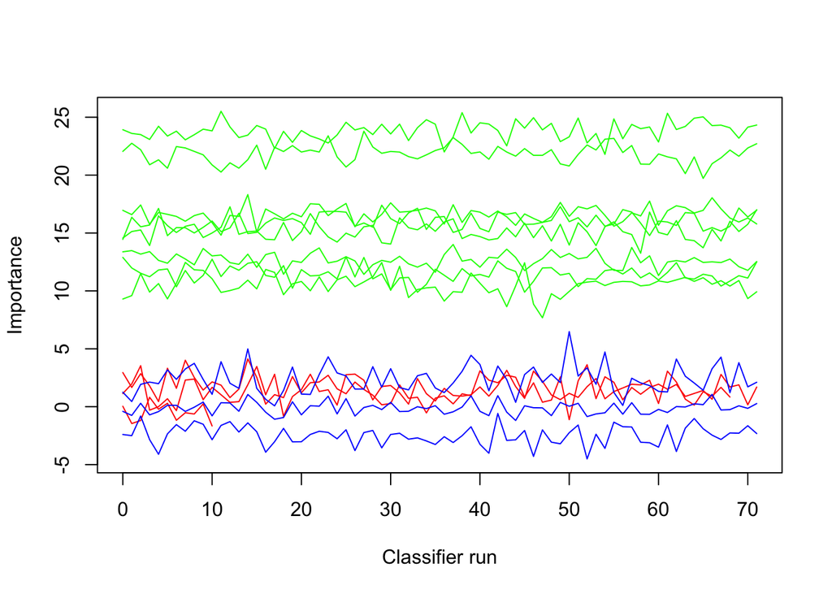

```r
plotImpHistory(Boruta.Ozone)
```

```r
library(titanic)

data(titanic_train)
```

```r
library(tidyverse)
library(janitor)
library(naniar)
library(Boruta)
```

```r
titanic_train <- titanic_train %>%
  mutate(
    Survived = as.factor(Survived),
    Pclass = as.factor(Pclass),
    Sex = as.factor(Sex),
    Embarked = as.factor(Embarked),
    Age = as.numeric(Age),
    SibSp = as.integer(SibSp),
    Parch = as.integer(Parch),
    Fare = as.numeric(Fare)
  ) %>%
  clean_names()
```

```r
# Check for duplicates
if (any(duplicated(titanic_train))) {
  titanic_train <- titanic_train[!duplicated(titanic_train), ]
}
```

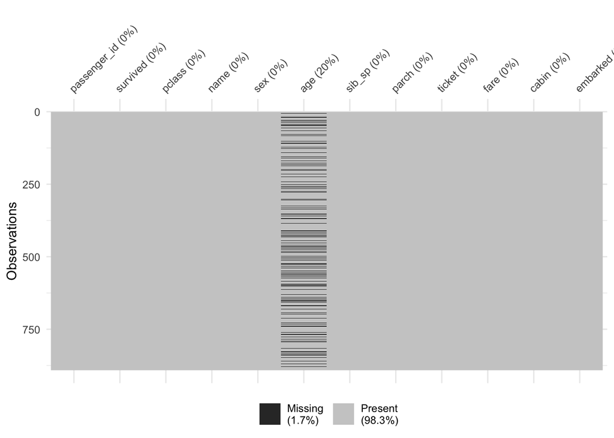

```r
# Visualize missing values
vis_miss(titanic_train)
```

```r
titanic_train <- drop_na(titanic_train)
```

```r
set.seed(123) # Set seed
boruta_output <- Boruta(survived ~ ., data = titanic_train, doTrace = 0)
```

```r
print(boruta_output)
```

```
Boruta performed 99 iterations in 13.78963 secs.
 9 attributes confirmed important: age, cabin, embarked, fare, parch
and 4 more;
 1 attributes confirmed unimportant: passenger_id;
 1 tentative attributes left: name;
```

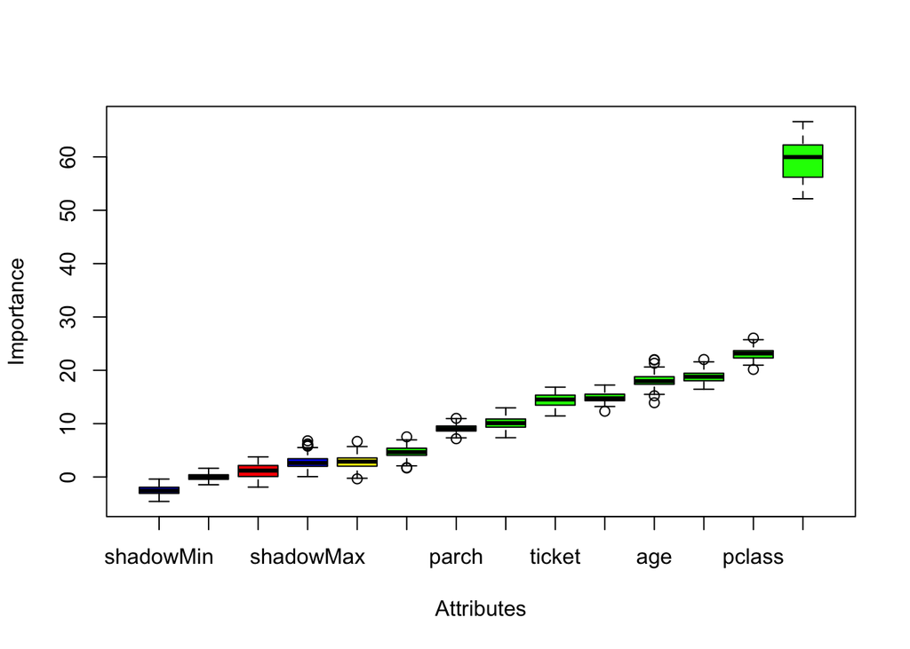

```r
plot(boruta_output)
```

```r
TentativeRoughFix(boruta_output)
```

```
Boruta performed 99 iterations in 13.78963 secs.
Tentatives roughfixed over the last 99 iterations.
 10 attributes confirmed important: age, cabin, embarked, fare, name
and 5 more;
 1 attributes confirmed unimportant: passenger_id;
```

```r
boruta_stats <- attStats(boruta_output)
confirmed_vars <- rownames(boruta_stats[boruta_stats$decision == 'Confirmed', ])
print(confirmed_vars)
```

```
[1] "pclass"   "sex"      "age"      "sib_sp"   "parch"    "ticket"   "fare"
[8] "cabin"    "embarked"
```

```r
attStats(boruta_output)
```

```
               meanImp medianImp     minImp    maxImp   normHits  decision
passenger_id  1.206684  1.188360 -1.9016874  3.767672 0.07070707  Rejected
pclass       23.076240 23.152310 20.1581012 26.044939 1.00000000 Confirmed
name          2.865374  2.880050 -0.3530274  6.671524 0.51515152 Tentative
sex          59.557745 59.969972 52.1565923 66.615458 1.00000000 Confirmed
age          18.076646 17.962988 13.9168176 22.000474 1.00000000 Confirmed
sib_sp       10.098391 10.094225  7.3611758 12.955136 1.00000000 Confirmed
parch         9.070120  9.052553  7.1622414 10.991798 1.00000000 Confirmed
ticket       14.420572 14.522849 11.4377621 16.838789 1.00000000 Confirmed
fare         18.808506 18.784795 16.4514404 22.023171 1.00000000 Confirmed
cabin        14.891208 14.740197 12.3152647 17.231526 1.00000000 Confirmed
embarked      4.671946  4.651714  1.6780783  7.527297 0.85858586 Confirmed
```

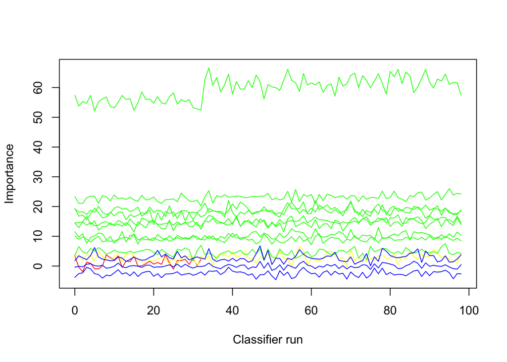

```r
plotImpHistory(boruta_output)
```